# RNA-seq Analysis Project

2022-07-01

## The Experiment

### RNA-seq of induced pluripotent stem cells from monozygotic twins discordant for trisomy 21

### [Link Here](https://europepmc.org/article/MED/24375627)

## The Experiment

Down syndrome (trisomy 21) is the most common viable chromosomal disorder with intellectual impairment and several other developmental abnormalities. The experiment report the generation and characterization of induced pluripotent stem cells (iPSCs) derived from monozygotic twins discordant for trisomy 21 in order to eliminate the effects of the variability of genomic background.

## The Experiment

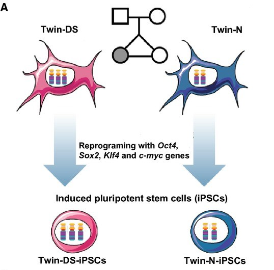

## The Experiment

The alterations observed by genetic analysis at the iPSC level and at first approximation in early development illustrate the developmental disease transcriptional signature of Down syndrome. Moreover, we observed an abnormal neural differentiation of Down syndrome iPSCs in vivo when formed teratoma in NOD-SCID mice, and in vitro when differentiated into neuroprogenitors and neurons. These defects were associated with changes in the architecture and density of neurons, astroglial and oligodendroglial cells together with misexpression of genes involved in neurogenesis, lineage specification and differentiation.

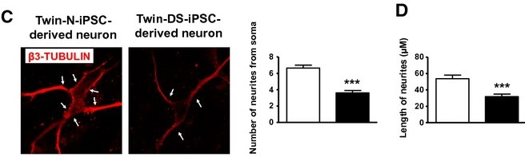

## mRNAseq Analysis

First of all I opened the raw counts file and the experimental design file that I had found from **Expression Atlas**. It contains 7 samples (SRR1028343 - SRR1028349), 4 of them from the Normal twin and 3 from the Down syndrome

```r
counts <- read.delim(file = 'E-GEOD-52249-raw-counts.tsv',
                     header = TRUE, row.names = 1)  # row counts dataset
counts <- counts[-1] # removing genes symbols column, necessary for DESeq analysis
```

Row Counts Data:

|  | SRR1028343 | SRR1028346 | SRR1028347 | SRR1028344 | SRR1028349 | SRR1028348 | SRR1028345 |
| --- | --- | --- | --- | --- | --- | --- | --- |
| ENSG00000000003 | 2909 | 6362 | 2277 | 2483 | 3286 | 4221 | 5446 |
| ENSG00000000005 | 33 | 73 | 12 | 53 | 29 | 26 | 45 |
| ENSG00000000419 | 1035 | 1726 | 1124 | 1060 | 2537 | 3113 | 1453 |
| ENSG00000000457 | 339 | 641 | 195 | 244 | 255 | 318 | 549 |
| ENSG00000000460 | 483 | 1208 | 571 | 522 | 881 | 1045 | 1116 |
| ENSG00000000938 | 7 | 13 | 18 | 6 | 18 | 19 | 12 |

## mRNAseq Analysis

```r
sampledata <- read.delim(file = 'E-GEOD-52249-experiment-design.tsv',
                         header = TRUE,
                         row.names = 1,
                         stringsAsFactors = TRUE)
```

Than I sorted the sampledata rows by rownames and counts coloumn by names. I did so because I was obtaining an error while trying to use the `DESeqDataSetFromMatrix()` function

```r
sampledata <-sampledata[order(row.names(sampledata)), ] # sorting them by gene ids
counts <- counts[ , order(names(counts))]
```

## mRNAseq Analysis

Ready to run the `DESeqDataSetFromMatrix()`

```r
suppressPackageStartupMessages(library(DESeq2))
dds <- DESeqDataSetFromMatrix(countData = counts,
                              colData = sampledata,
                              design = as.formula("~ Factor.Value.disease."))
dds # having a first look to the data - 58735 genes
```

```
class: DESeqDataSet
dim: 58735 7
metadata(1): version
assays(1): counts
rownames(58735): ENSG00000000003 ENSG00000000005 ... ENSG00000285993
  ENSG00000285994
rowData names(0):
colnames(7): SRR1028343 SRR1028344 ... SRR1028348 SRR1028349
colData names(21): Sample.Characteristic.cell.type.
  Sample.Characteristic.Ontology.Term.cell.type. ...
  Factor.Value.Ontology.Term.disease. Analysed
```

As design i wrote the column name of the sampledata obj containing the classification group of the samples

## mRNAseq Analysis

Before the `DESeq()` piplines I filtered the dataset for the low expressed genes to improve the analysis

```r
keep <- rowSums(counts(dds)) > 1 # removing every genes with less than 1 counts
dds <- dds[keep, ]               # as sum of the row
dds # now I have just 38233 genes
```

```
class: DESeqDataSet
dim: 38233 7
metadata(1): version
assays(1): counts
rownames(38233): ENSG00000000003 ENSG00000000005 ... ENSG00000285993
  ENSG00000285994
rowData names(0):
colnames(7): SRR1028343 SRR1028344 ... SRR1028348 SRR1028349
colData names(21): Sample.Characteristic.cell.type.
  Sample.Characteristic.Ontology.Term.cell.type. ...
  Factor.Value.Ontology.Term.disease. Analysed
```

## mRNAseq Analysis

After that I proceeded with the pipeline, `DESeq()` normalizes the counts and do estimation of dispersion values

```r
dds <- DESeq(dds)
```

Than I create a PCA plot. In order to do that I used `vst()` function to normalize, it is more sensitive to library size than `'rlog()`.

```r
vsd <- varianceStabilizingTransformation(dds)
```

## mRNAseq Analysis

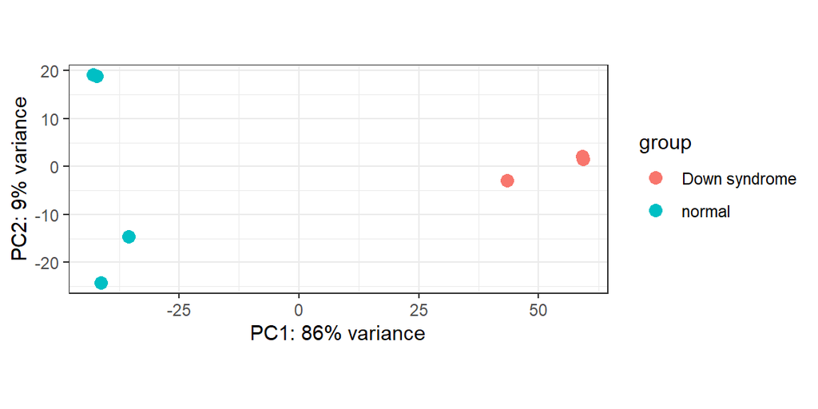

```r
plotPCA(vsd, intgroup = 'Factor.Value.disease.') +
  theme_bw()
```

From the PCA plots seems that all samples are correctly classified. Low variance between same group samples and high between different ones

## mRNAseq Analysis

Now the sample distance heatmap plot. First of all I proDuced analysis of distances of samples and an obj for the palette of colors of the graph

```r
sampleDists <- dist(t(assay(vsd)))
sampleDistMatrix <- as.matrix( sampleDists )
colors <- colorRampPalette( rev(brewer.pal(9, "Blues")) )(255)
```

|  | SRR1028343 | SRR1028344 | SRR1028345 | SRR1028346 | SRR1028347 | SRR1028348 | SRR1028349 |
| --- | --- | --- | --- | --- | --- | --- | --- |
| SRR1028343 | 0.00000 | 98.26965 | 127.88676 | 125.80487 | 176.0338 | 192.69067 | 192.83669 |
| SRR1028344 | 98.26965 | 0.00000 | 120.78927 | 119.26652 | 159.7133 | 172.49762 | 172.88836 |
| SRR1028345 | 127.88676 | 120.78927 | 0.00000 | 61.02137 | 187.0110 | 192.13793 | 194.60405 |
| SRR1028346 | 125.80487 | 119.26652 | 61.02137 | 0.00000 | 186.1807 | 192.65437 | 194.02698 |
| SRR1028347 | 176.03380 | 159.71326 | 187.01098 | 186.18074 | 0.0000 | 117.84139 | 117.95140 |
| SRR1028348 | 192.69067 | 172.49762 | 192.13793 | 192.65437 | 117.8414 | 0.00000 | 68.65255 |
| SRR1028349 | 192.83669 | 172.88836 | 194.60405 | 194.02698 | 117.9514 | 68.65255 | 0.00000 |

## mRNAseq Analysis

Darker is the color, more similar are the samples; trees represent the gerarchy of cluster. The heatmap suggest that all samples are correctly classified, DS samples are similar each other and same for Normal ones, as the PCA did.

```r
# creating the Heat map
pheatmap(sampleDistMatrix,
         clustering_distance_rows = sampleDists,
         clustering_distance_cols = sampleDists,
         col = colors)
```

## mRNAseq Analysis

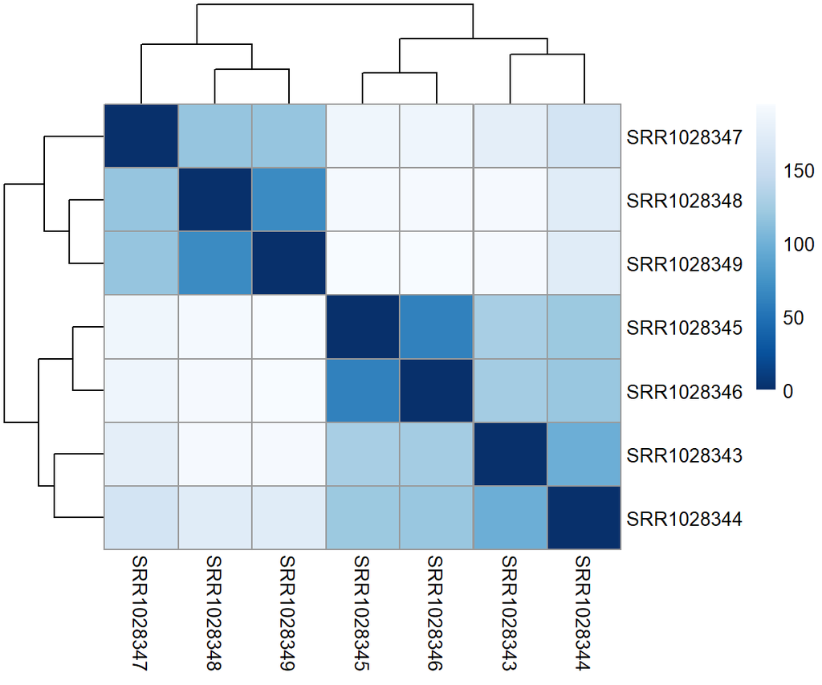

## mRNAseq Analysis

Than I performed the comparison between the two groups. I specified the coloumn of sampledata (experimental design) that has the group classification: Down syndrome vs Normal. 5241 genes are over overexpressed in DS while 5374 underexpressed

```r
DEresults <- results(dds,
                     contrast = c("Factor.Value.disease.", 'Down syndrome', 'normal'))
summary(DEresults)
```

```
out of 38233 with nonzero total read count
adjusted p-value < 0.1
LFC > 0 (up)       : 5241, 14%
LFC < 0 (down)     : 5374, 14%
outliers [1]       : 42, 0.11%
low counts [2]     : 9636, 25%
(mean count < 1)
[1] see 'cooksCutoff' argument of ?results
[2] see 'independentFiltering' argument of ?results
```

## mRNAseq Analysis

Ordering the genes by fold change

```r
DEresults <- DEresults[order(-abs(DEresults$log2FoldChange)), ]
```

|  | baseMean | log2FoldChange | lfcSE | stat | pvalue | padj |
| --- | --- | --- | --- | --- | --- | --- |
| ENSG00000164778 | 1035.5468 | -13.16024 | 1.6519066 | -7.966698 | 0 | 0 |
| ENSG00000268658 | 417.4259 | 12.46695 | 1.0343089 | 12.053412 | 0 | 0 |
| ENSG00000213973 | 312.5052 | 12.05037 | 1.3661703 | 8.820545 | 0 | 0 |
| ENSG00000279377 | 2093.7550 | 11.67793 | 0.6478677 | 18.025184 | 0 | 0 |
| ENSG00000179059 | 4570.3773 | 11.50732 | 0.4105770 | 28.027192 | 0 | 0 |
| ENSG00000160321 | 1869.5643 | 11.31898 | 0.6194550 | 18.272477 | 0 | 0 |

## mRNAseq Analysis

Comparison of my results to results section of the **Expression Atlas**. Some examples:

```r
DEresults['ENSG00000229807',]
```

```
log2 fold change (MLE): Factor.Value.disease. Down syndrome vs normal
Wald test p-value: Factor.Value.disease. Down syndrome vs normal
DataFrame with 1 row and 6 columns
                 baseMean log2FoldChange     lfcSE      stat      pvalue
                <numeric>      <numeric> <numeric> <numeric>   <numeric>
ENSG00000229807    9873.7       -10.4409  0.499009  -20.9233 3.28577e-97
                       padj
                  <numeric>
ENSG00000229807 5.21251e-94
```

```r
# XIST gene - it gives a fold of -10 instead of -9.6 on publication
```